# tableone 패키지 소개

yujin

2022 1 20

# 시작하기 전에

본 자료는 데이터셋의 모든 변수를 하나의 테이블로 요약하는 방법에 대해 알아볼 것이다. **tableone** 패키지를 이용하면 효율적으로 논문에 들어갈 table1을 만들 수 있다.

# What is tableone?

`tableone`은 의학 연구 논문에서 볼 수 있는 table1을 구성하는 데 사용되는 패키지로, 한 테이블 내에 혼합된 범주형 변수와 연속형 변수를 모두 요약할 수 있고 사용법이 매우 간단하다는 장점이 있다.

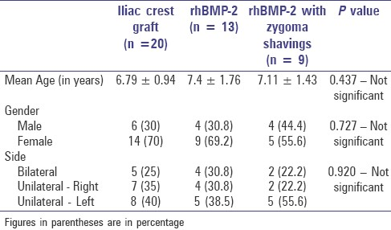

# Creating a tableone

```r
# install.packages("data.table")
# install.packages("curl")
# install.packages("tableone")

library(data.table)
library(curl)
library(tableone)
```

```r
url <- "https://raw.githubusercontent.com/jinseob2kim/lecture-snuhlab/master/data/example_g1e.csv"
(dt <- fread(url,header=T))
```

| EXMD_BZ_YYYY | RN_INDI | HME_YYYYMM | Q_PHX_DX_STK | Q_PHX_DX_HTDZ | Q_PHX_DX_HTN | Q_PHX_DX_DM | Q_PHX_DX_DLD | Q_PHX_DX_PTB | Q_HBV_AG | Q_SMK_YN | Q_DRK_FRQ_V09N | HGHT | WGHT | WSTC | BMI | VA_LT | VA_RT | BP_SYS | BP_DIA | URN_PROT | HGB | FBS | TOT_CHOL | TG | HDL | LDL | CRTN | SGOT | SGPT | … |
| --- | --- | --- | --- | --- | --- | --- | --- | --- | --- | --- | --- | --- | --- | --- | --- | --- | --- | --- | --- | --- | --- | --- | --- | --- | --- | --- | --- | --- | --- | --- |
| 2009 | 562083 | 200909 | 0 | 0 | 1 | 0 | 0 | NA | 3 | 1 | 0 | 144 | 61 | 90 | 29.4 | 0.7 | 0.8 | 120 | 80 | 1 | 12.6 | 117 | 264 | 128 | 60 | 179 | 0.9 | 25 | 20 | … |
| 2009 | 334536 | 200911 | 0 | 0 | 0 | 0 | 0 | NA | 2 | 1 | 0 | 162 | 51 | 63 | 19.4 | 0.8 | 1.0 | 120 | 80 | 1 | 13.8 | 96 | 169 | 92 | 70 | 80 | 0.9 | 18 | 15 | … |
| 2009 | 911867 | 200903 | 0 | 0 | 0 | 0 | 0 | NA | 3 | 1 | 0 | 163 | 65 | 82 | 24.5 | 0.7 | 0.6 | 130 | 80 | 1 | 15.0 | 118 | 216 | 132 | 55 | 134 | 0.8 | 26 | 30 | … |
| 2009 | 183321 | 200908 | NA | NA | NA | NA | NA | NA | 3 | 1 | 0 | 152 | 51 | 70 | 22.1 | 0.8 | 0.9 | 101 | 62 | 1 | 13.1 | 90 | 199 | 100 | 65 | 114 | 0.9 | 18 | 14 | … |
| 2009 | 942671 | 200909 | NA | NA | NA | NA | NA | NA | 3 | 1 | 0 | 159 | 50 | 73 | 19.8 | 0.7 | 0.8 | 132 | 78 | 1 | 13.0 | 92 | 162 | 58 | 40 | 111 | 0.9 | 24 | 23 | … |
| 2009 | 979358 | 200912 | NA | NA | NA | NA | NA | NA | 2 | 1 | 0 | 157 | 55 | 73 | 22.3 | 1.5 | 1.5 | 110 | 70 | 1 | 11.9 | 100 | 192 | 109 | 53 | 117 | 0.7 | 15 | 12 | … |
| 2009 | 554112 | 200911 | NA | NA | NA | NA | NA | NA | 2 | 1 | 0 | 160 | 56 | 67 | 21.9 | 1.5 | 1.5 | 119 | 78 | 1 | 11.2 | 84 | 152 | 38 | 43 | 101 | 0.8 | 8 | 6 | … |
| 2009 | 487160 | 200908 | NA | NA | NA | NA | NA | NA | 3 | 1 | 0 | 159 | 54 | 66 | 21.4 | 1.2 | 1.5 | 111 | 60 | 1 | 12.2 | 88 | 166 | 42 | 58 | 99 | 1.0 | 16 | 11 | … |
| 2009 | 793017 | 200906 | NA | NA | NA | NA | NA | NA | 3 | 1 | 0 | 156 | 53 | 67 | 21.8 | 1.2 | 1.0 | 138 | 72 | 1 | 11.0 | 74 | 155 | 86 | 52 | 85 | 0.6 | 15 | 13 | … |
| 2009 | 219397 | 200912 | 0 | 0 | 1 | 0 | 0 | NA | 3 | 1 | 0 | 146 | 48 | 78 | 22.5 | 1.5 | 1.5 | 138 | 84 | 1 | 12.8 | 107 | 178 | 87 | 35 | 125 | 0.7 | 21 | 21 | … |

[output cut: 1634 more lines]

```r
# create table1
CreateTableOne(data=dt)
```

```
##
##                              Overall
##   n                               1644
##   EXMD_BZ_YYYY (mean (SD))     2012.08 (1.99)
##   RN_INDI (mean (SD))        490782.25 (290056.68)
##   HME_YYYYMM (mean (SD))     201216.18 (199.11)
##   Q_PHX_DX_STK (mean (SD))        0.01 (0.11)
##   Q_PHX_DX_HTDZ (mean (SD))       0.02 (0.15)
##   Q_PHX_DX_HTN (mean (SD))        0.25 (0.43)
##   Q_PHX_DX_DM (mean (SD))         0.07 (0.25)
##   Q_PHX_DX_DLD (mean (SD))        0.04 (0.20)
##   Q_PHX_DX_PTB (mean (SD))        0.03 (0.16)
##   Q_HBV_AG (mean (SD))            2.24 (0.52)
##   Q_SMK_YN (mean (SD))            1.63 (0.84)
##   Q_DRK_FRQ_V09N (mean (SD))      1.03 (1.39)
##   HGHT (mean (SD))              164.55 (9.19)
##   WGHT (mean (SD))               65.10 (12.53)
##   WSTC (mean (SD))               80.69 (9.55)
##   BMI (mean (SD))                23.92 (3.38)
##   VA_LT (mean (SD))               0.98 (0.56)
##   VA_RT (mean (SD))               0.98 (0.56)
##   BP_SYS (mean (SD))            122.26 (14.63)
##   BP_DIA (mean (SD))             76.60 (10.06)
##   URN_PROT (mean (SD))            1.08 (0.40)
##   HGB (mean (SD))                14.11 (1.69)
##   FBS (mean (SD))                97.23 (20.13)
##   TOT_CHOL (mean (SD))          194.93 (36.57)
##   TG (mean (SD))                134.90 (104.75)
##   HDL (mean (SD))                55.90 (19.47)
##   LDL (mean (SD))               118.69 (201.99)
##   CRTN (mean (SD))                0.99 (1.02)
##   SGOT (mean (SD))               25.60 (16.18)
##   SGPT (mean (SD))               25.98 (27.18)
##   GGT (mean (SD))                36.34 (36.43)
##   GFR (mean (SD))                89.74 (21.71)
```

범주형 변수는 개수(백분율)로 요약된다. 연속형 변수는 normal인 경우 mean(sd)로 나타나고, nonnormal인 경우 median(IQR)로 요약된다.

# Argument customize

**CreateTableOne()** 함수에는 다양한 옵션이 존재한다. 세부적인 옵션 설정을 통해 원하는 table1을 만들 수 있다. 주요 옵션은 다음과 같다.

- `CreateTableOne`
  - vars : 테이블에 들어갈 변수들
  - factorVars : 범주형 변수들
  - data : 데이터
  - strata : 그룹 변수 지정
  - includeNA : 범주형 변수에서 `NA`를 하나의 범주로 포함할지 여부

옵션에 대한 자세한 설명은 예시를 통해 다루도록 하겠다.

## Categorical variable conversion

**factorVars** 인자를 사용하여 범주형 변수를 지정할 수 있다. 이때 **vars** 인자를 통해 전체 데이터 셋 중 테이블에 들어갈 변수를 설정할 수 있고, 지정하지 않을 시 데이터 셋의 모든 변수가 포함된다.

```r
# Variables
myVars <- c("HGHT", "WGHT", "BMI", "HDL", "LDL", "TG", "SGPT",
            "Q_PHX_DX_STK", "Q_PHX_DX_HTDZ", "Q_HBV_AG", "Q_SMK_YN")

# Categorical variables
catVars <- c("Q_PHX_DX_STK", "Q_PHX_DX_HTDZ", "Q_HBV_AG", "Q_SMK_YN")

t1 <- CreateTableOne(vars = myVars, factorVars = catVars, data = dt)
t1
```

```
##
##                         Overall
##   n                       1644
##   HGHT (mean (SD))      164.55 (9.19)
##   WGHT (mean (SD))       65.10 (12.53)
##   BMI (mean (SD))        23.92 (3.38)
##   HDL (mean (SD))        55.90 (19.47)
##   LDL (mean (SD))       118.69 (201.99)
##   TG (mean (SD))        134.90 (104.75)
##   SGPT (mean (SD))       25.98 (27.18)
##   Q_PHX_DX_STK = 1 (%)      12 ( 1.1)
##   Q_PHX_DX_HTDZ = 1 (%)     26 ( 2.4)
##   Q_HBV_AG (%)
##      1                      77 ( 4.7)
##      2                    1102 (67.1)
##      3                     463 (28.2)
##   Q_SMK_YN (%)
##      1                     995 (60.6)
##      2                     256 (15.6)
##      3                     391 (23.8)
```

- 범주형 변수로 설정한 컬럼의 요약값이 mean(sd)에서 n(percentage)로 바뀐 것을 볼 수 있다.
- 두 개의 범주가 있는 범주형 변수의 경우, 두 번째 범주의 요약값만 출력된다. 예를 들어 0과 1의 범주가 있을 때, 범주1의 개수와 백분율이 출력된다. 이는 옵션 설정을 통해 전체 범주의 요약값을 출력하도록 변경할 수 있다.
- 3개 이상의 범주가 있을 때에는 모든 범주의 값이 요약되며, 백분율은 누락된 값을 제외한 후 계산된다.

## Multiple group summary

**strata** 인자를 설정하여 그룹별 연산을 할 수 있다. **strata**는 dplyr 패키지의 group_by() 함수와 유사하며, 그룹 연산을 할 변수를 지정하여 사용할 수 있다.

```r
t2 <- CreateTableOne(data = dt,
                     vars = myVars,
                     strata = "Q_SMK_YN",
                     factorVars = catVars,
                     includeNA = F)
t2
```

```
##                        Stratified by Q_SMK_YN
##                         1               2               3               p
##   n                        995             256             391
##   HGHT (mean (SD))      160.67 (8.34)   168.83 (6.45)   171.61 (7.09)   <0.001
##   WGHT (mean (SD))       61.17 (11.08)   70.09 (10.72)   71.76 (13.07)  <0.001
##   BMI (mean (SD))        23.63 (3.39)    24.52 (2.93)    24.27 (3.54)   <0.001
##   HDL (mean (SD))        57.83 (14.08)   53.91 (36.73)   52.37 (13.54)  <0.001
##   LDL (mean (SD))       112.26 (32.81)  147.52 (505.27) 116.34 (56.89)   0.046
##   TG (mean (SD))        114.05 (76.97)  162.89 (126.51) 169.24 (133.28) <0.001
##   SGPT (mean (SD))       23.33 (28.42)   28.61 (20.62)   31.00 (26.96)  <0.001
##   Q_PHX_DX_STK = 1 (%)      11 (  1.8)       1 (  0.5)       0 (  0.0)   0.051
##   Q_PHX_DX_HTDZ = 1 (%)     18 (  2.9)       5 (  2.6)       3 (  1.1)   0.287
##   Q_HBV_AG (%)                                                           0.193
##      1                      40 (  4.0)      19 (  7.5)      17 (  4.3)
##      2                     679 ( 68.3)     164 ( 64.3)     259 ( 66.2)
##      3                     275 ( 27.7)      72 ( 28.2)     115 ( 29.4)
##   Q_SMK_YN (%)                                                          <0.001
##      1                     995 (100.0)       0 (  0.0)       0 (  0.0)
##      2                       0 (  0.0)     256 (100.0)       0 (  0.0)
##      3                       0 (  0.0)       0 (  0.0)     391 (100.0)
##                        Stratified by Q_SMK_YN
##                         test
##   n
##   HGHT (mean (SD))
##   WGHT (mean (SD))
##   BMI (mean (SD))
##   HDL (mean (SD))
##   LDL (mean (SD))
##   TG (mean (SD))
##   SGPT (mean (SD))
##   Q_PHX_DX_STK = 1 (%)
##   Q_PHX_DX_HTDZ = 1 (%)
##   Q_HBV_AG (%)
##      1
##      2
##      3
##   Q_SMK_YN (%)
##      1
##      2
##      3
```

연속형 변수의 경우, 기본적으로 one-way ANOVA test가 적용되며 nonnormal일 경우 옵션 설정을 통해 Kruskal–Wallis one-way ANOVA test를 적용할 수 있다.

범주형 변수의 경우, 기본적으로 chisq-test가 적용되며 print 함수의 exact 옵션 설정을 통해 fisher-test를 적용할 수 있다.

## Detailed information including missingness

`summary` 함수를 쓰면 누락값을 포함한 table1의 자세한 정보를 알 수 있다. 연속형 변수의 값들이 먼저 출력되며 그 다음으로 범주형 변수의 요약값이 출력된다.

```r
summary(t1)
```

```
##
##      ### Summary of continuous variables ###
##
## strata: Overall
##         n miss p.miss mean  sd median p25 p75 min  max skew   kurt
## HGHT 1644    0      0  165   9    165 158 171 134  188 -0.2   -0.3
## WGHT 1644    0      0   65  13     64  56  73  31  118  0.7    1.0
## BMI  1644    0      0   24   3     24  22  26  12   37  0.4    0.4
## HDL  1644    0      0   56  19     54  46  64  23  593 13.1  352.2
## LDL  1644   16      1  119 202    112  90 134  19 8100 38.0 1501.0
## TG   1644    0      0  135 105    106  72 163  13 1210  3.4   20.2
## SGPT 1644    0      0   26  27     20  15  30   3  779 15.0  374.4
##
## =======================================================================================
##
##      ### Summary of categorical variables ###
##
## strata: Overall
##            var    n miss p.miss level freq percent cum.percent
##   Q_PHX_DX_STK 1644  573   34.9     0 1059    98.9        98.9
##                                     1   12     1.1       100.0
##
##  Q_PHX_DX_HTDZ 1644  566   34.4     0 1052    97.6        97.6
##                                     1   26     2.4       100.0
##
##       Q_HBV_AG 1644    2    0.1     1   77     4.7         4.7
##                                     2 1102    67.1        71.8
##                                     3  463    28.2       100.0
##
##       Q_SMK_YN 1644    2    0.1     1  995    60.6        60.6
##                                     2  256    15.6        76.2
##                                     3  391    23.8       100.0
##
```

## Show categorical or continuous variable only

앞에서 만든 table1에서 연속형 변수와 범주형 변수를 구분하여 출력할 수 있다. **“$”**를 사용하여 연속형 변수는 ConTable, 범주형 변수는 CaTable을 쓰면 해당 변수를 따로 출력할 수 있다.

```r
# Categorical variables
t2$CatTable
```

```
##                        Stratified by Q_SMK_YN
##                         1            2            3            p      test
##   n                     995          256          391
##   Q_PHX_DX_STK = 1 (%)   11 (  1.8)    1 (  0.5)    0 (  0.0)   0.051
##   Q_PHX_DX_HTDZ = 1 (%)  18 (  2.9)    5 (  2.6)    3 (  1.1)   0.287
##   Q_HBV_AG (%)                                                  0.193
##      1                   40 (  4.0)   19 (  7.5)   17 (  4.3)
##      2                  679 ( 68.3)  164 ( 64.3)  259 ( 66.2)
##      3                  275 ( 27.7)   72 ( 28.2)  115 ( 29.4)
##   Q_SMK_YN (%)                                                 <0.001
##      1                  995 (100.0)    0 (  0.0)    0 (  0.0)
##      2                    0 (  0.0)  256 (100.0)    0 (  0.0)
##      3                    0 (  0.0)    0 (  0.0)  391 (100.0)
```

```r
# Continuous variables
t2$ContTable
```

```
##                   Stratified by Q_SMK_YN
##                    1              2               3               p      test
##   n                995            256             391
##   HGHT (mean (SD)) 160.67 (8.34)  168.83 (6.45)   171.61 (7.09)   <0.001
##   WGHT (mean (SD))  61.17 (11.08)  70.09 (10.72)   71.76 (13.07)  <0.001
##   BMI (mean (SD))   23.63 (3.39)   24.52 (2.93)    24.27 (3.54)   <0.001
##   HDL (mean (SD))   57.83 (14.08)  53.91 (36.73)   52.37 (13.54)  <0.001
##   LDL (mean (SD))  112.26 (32.81) 147.52 (505.27) 116.34 (56.89)   0.046
##   TG (mean (SD))   114.05 (76.97) 162.89 (126.51) 169.24 (133.28) <0.001
##   SGPT (mean (SD))  23.33 (28.42)  28.61 (20.62)   31.00 (26.96)  <0.001
```

# print argument customize

**CreateTableOne()** 함수를 사용하여 테이블을 만든 후, **print** 명령어로 세부 옵션을 지정할 수 있다. 주요 옵션은 다음과 같다.

- `print`
  - showAllLevels, cramVars : 2범주인 변수에서 2범주를 다 보여줄 변수
  - nonnormal : 비모수통계를 쓸 연속 변수
  - exact : fisher-test를 쓸 범주형 변수
  - smd : standardized mean difference

## Showing all levels for categorical variables

범주형 변수에서 모든 범주의 요약값을 확인하려면 **ShowAllLevels** 또는 **cramVars** 옵션을 사용한다. ShowAllLevels = T 를 설정하거나 cramVars 옵션에 원하는 변수명을 지정하여 사용할 수 있다.

- 1.use **showAllLevels**

```r
print(t1, showAllLevels = T)
```

```
##
##                     level Overall
##   n                         1644
##   HGHT (mean (SD))        164.55 (9.19)
##   WGHT (mean (SD))         65.10 (12.53)
##   BMI (mean (SD))          23.92 (3.38)
##   HDL (mean (SD))          55.90 (19.47)
##   LDL (mean (SD))         118.69 (201.99)
##   TG (mean (SD))          134.90 (104.75)
##   SGPT (mean (SD))         25.98 (27.18)
##   Q_PHX_DX_STK (%)  0       1059 (98.9)
##                     1         12 ( 1.1)
##   Q_PHX_DX_HTDZ (%) 0       1052 (97.6)
##                     1         26 ( 2.4)
##   Q_HBV_AG (%)      1         77 ( 4.7)
##                     2       1102 (67.1)
##                     3        463 (28.2)
##   Q_SMK_YN (%)      1        995 (60.6)
##                     2        256 (15.6)
##                     3        391 (23.8)
```

- 2.use **cramVars**

```r
print(t1, cramVars="Q_PHX_DX_STK")
```

```
##
##                          Overall
##   n                         1644
##   HGHT (mean (SD))        164.55 (9.19)
##   WGHT (mean (SD))         65.10 (12.53)
##   BMI (mean (SD))          23.92 (3.38)
##   HDL (mean (SD))          55.90 (19.47)
##   LDL (mean (SD))         118.69 (201.99)
##   TG (mean (SD))          134.90 (104.75)
##   SGPT (mean (SD))         25.98 (27.18)
##   Q_PHX_DX_STK = 0/1 (%) 1059/12 (98.9/1.1)
##   Q_PHX_DX_HTDZ = 1 (%)       26 ( 2.4)
##   Q_HBV_AG (%)
##      1                        77 ( 4.7)
##      2                      1102 (67.1)
##      3                       463 (28.2)
##   Q_SMK_YN (%)
##      1                       995 (60.6)
##      2                       256 (15.6)
##      3                       391 (23.8)
```

## Summarizing nonnormal variables

비모수통계를 사용하는 연속형 변수에는 **nonnormal** 옵션을 설정한다. nonnormal 설정 시 mean(sd)에서 median(IQR)로 요약값이 변경된다.

```r
print(t1, nonnormal="LDL")
```

```
##
##                         Overall
##   n                       1644
##   HGHT (mean (SD))      164.55 (9.19)
##   WGHT (mean (SD))       65.10 (12.53)
##   BMI (mean (SD))        23.92 (3.38)
##   HDL (mean (SD))        55.90 (19.47)
##   LDL (median [IQR])    112.00 [90.00, 134.00]
##   TG (mean (SD))        134.90 (104.75)
##   SGPT (mean (SD))       25.98 (27.18)
##   Q_PHX_DX_STK = 1 (%)      12 ( 1.1)
##   Q_PHX_DX_HTDZ = 1 (%)     26 ( 2.4)
##   Q_HBV_AG (%)
##      1                      77 ( 4.7)
##      2                    1102 (67.1)
##      3                     463 (28.2)
##   Q_SMK_YN (%)
##      1                     995 (60.6)
##      2                     256 (15.6)
##      3                     391 (23.8)
```

## exact

**exact** 옵션을 통해 fisher-test를 진행할 범주형 변수를 설정할 수 있다. 범주형 변수는 기본적으로 chisq-test가 적용되며, exact 옵션에 fisher-test를 적용할 변수를 지정하여 사용할 수 있다.

```r
print(t2,
      exact=c("Q_PHX_DX_STK", "Q_PHX_DX_HTDZ"))
```

```
##                        Stratified by Q_SMK_YN
##                         1               2               3               p
##   n                        995             256             391
##   HGHT (mean (SD))      160.67 (8.34)   168.83 (6.45)   171.61 (7.09)   <0.001
##   WGHT (mean (SD))       61.17 (11.08)   70.09 (10.72)   71.76 (13.07)  <0.001
##   BMI (mean (SD))        23.63 (3.39)    24.52 (2.93)    24.27 (3.54)   <0.001
##   HDL (mean (SD))        57.83 (14.08)   53.91 (36.73)   52.37 (13.54)  <0.001
##   LDL (mean (SD))       112.26 (32.81)  147.52 (505.27) 116.34 (56.89)   0.046
##   TG (mean (SD))        114.05 (76.97)  162.89 (126.51) 169.24 (133.28) <0.001
##   SGPT (mean (SD))       23.33 (28.42)   28.61 (20.62)   31.00 (26.96)  <0.001
##   Q_PHX_DX_STK = 1 (%)      11 (  1.8)       1 (  0.5)       0 (  0.0)   0.045
##   Q_PHX_DX_HTDZ = 1 (%)     18 (  2.9)       5 (  2.6)       3 (  1.1)   0.281
##   Q_HBV_AG (%)                                                           0.193
##      1                      40 (  4.0)      19 (  7.5)      17 (  4.3)
##      2                     679 ( 68.3)     164 ( 64.3)     259 ( 66.2)
##      3                     275 ( 27.7)      72 ( 28.2)     115 ( 29.4)
##   Q_SMK_YN (%)                                                          <0.001
##      1                     995 (100.0)       0 (  0.0)       0 (  0.0)
##      2                       0 (  0.0)     256 (100.0)       0 (  0.0)
##      3                       0 (  0.0)       0 (  0.0)     391 (100.0)
##                        Stratified by Q_SMK_YN
##                         test
##   n
##   HGHT (mean (SD))
##   WGHT (mean (SD))
##   BMI (mean (SD))
##   HDL (mean (SD))
##   LDL (mean (SD))
##   TG (mean (SD))
##   SGPT (mean (SD))
##   Q_PHX_DX_STK = 1 (%)  exact
##   Q_PHX_DX_HTDZ = 1 (%) exact
##   Q_HBV_AG (%)
##      1
##      2
##      3
##   Q_SMK_YN (%)
##      1
##      2
##      3
```

## smd

**smd** 옵션을 통해 smd(standardized mean difference)를 table1에 포함할 수 있다. default는 FALSE이고, smd=TRUE 설정 시 각 변수의 smd 값이 출력된다.

```r
print(t2,
      smd = TRUE)
```

```
##                        Stratified by Q_SMK_YN
##                         1               2               3               p
##   n                        995             256             391
##   HGHT (mean (SD))      160.67 (8.34)   168.83 (6.45)   171.61 (7.09)   <0.001
##   WGHT (mean (SD))       61.17 (11.08)   70.09 (10.72)   71.76 (13.07)  <0.001
##   BMI (mean (SD))        23.63 (3.39)    24.52 (2.93)    24.27 (3.54)   <0.001
##   HDL (mean (SD))        57.83 (14.08)   53.91 (36.73)   52.37 (13.54)  <0.001
##   LDL (mean (SD))       112.26 (32.81)  147.52 (505.27) 116.34 (56.89)   0.046
##   TG (mean (SD))        114.05 (76.97)  162.89 (126.51) 169.24 (133.28) <0.001
##   SGPT (mean (SD))       23.33 (28.42)   28.61 (20.62)   31.00 (26.96)  <0.001
##   Q_PHX_DX_STK = 1 (%)      11 (  1.8)       1 (  0.5)       0 (  0.0)   0.051
##   Q_PHX_DX_HTDZ = 1 (%)     18 (  2.9)       5 (  2.6)       3 (  1.1)   0.287
##   Q_HBV_AG (%)                                                           0.193
##      1                      40 (  4.0)      19 (  7.5)      17 (  4.3)
##      2                     679 ( 68.3)     164 ( 64.3)     259 ( 66.2)
##      3                     275 ( 27.7)      72 ( 28.2)     115 ( 29.4)
##   Q_SMK_YN (%)                                                          <0.001
##      1                     995 (100.0)       0 (  0.0)       0 (  0.0)
##      2                       0 (  0.0)     256 (100.0)       0 (  0.0)
##      3                       0 (  0.0)       0 (  0.0)     391 (100.0)
##                        Stratified by Q_SMK_YN
##                         test SMD
##   n
##   HGHT (mean (SD))            0.972
##   WGHT (mean (SD))            0.611
##   BMI (mean (SD))             0.181
##   HDL (mean (SD))             0.197
##   LDL (mean (SD))             0.091
##   TG (mean (SD))              0.341
##   SGPT (mean (SD))            0.196
##   Q_PHX_DX_STK = 1 (%)        0.137
##   Q_PHX_DX_HTDZ = 1 (%)       0.084
##   Q_HBV_AG (%)                0.109
##      1
##      2
##      3
##   Q_SMK_YN (%)                  NaN
##      1
##      2
##      3
```

# Export tableone

`write.csv` 함수를 사용하여 table1을 csv파일로 저장할 수 있다.

```r
table1 <- print(t2)
```

```
##                        Stratified by Q_SMK_YN
##                         1               2               3               p
##   n                        995             256             391
##   HGHT (mean (SD))      160.67 (8.34)   168.83 (6.45)   171.61 (7.09)   <0.001
##   WGHT (mean (SD))       61.17 (11.08)   70.09 (10.72)   71.76 (13.07)  <0.001
##   BMI (mean (SD))        23.63 (3.39)    24.52 (2.93)    24.27 (3.54)   <0.001
##   HDL (mean (SD))        57.83 (14.08)   53.91 (36.73)   52.37 (13.54)  <0.001
##   LDL (mean (SD))       112.26 (32.81)  147.52 (505.27) 116.34 (56.89)   0.046
##   TG (mean (SD))        114.05 (76.97)  162.89 (126.51) 169.24 (133.28) <0.001
##   SGPT (mean (SD))       23.33 (28.42)   28.61 (20.62)   31.00 (26.96)  <0.001
##   Q_PHX_DX_STK = 1 (%)      11 (  1.8)       1 (  0.5)       0 (  0.0)   0.051
##   Q_PHX_DX_HTDZ = 1 (%)     18 (  2.9)       5 (  2.6)       3 (  1.1)   0.287
##   Q_HBV_AG (%)                                                           0.193
##      1                      40 (  4.0)      19 (  7.5)      17 (  4.3)
##      2                     679 ( 68.3)     164 ( 64.3)     259 ( 66.2)
##      3                     275 ( 27.7)      72 ( 28.2)     115 ( 29.4)
##   Q_SMK_YN (%)                                                          <0.001
##      1                     995 (100.0)       0 (  0.0)       0 (  0.0)
##      2                       0 (  0.0)     256 (100.0)       0 (  0.0)
##      3                       0 (  0.0)       0 (  0.0)     391 (100.0)
##                        Stratified by Q_SMK_YN
##                         test
##   n
##   HGHT (mean (SD))
##   WGHT (mean (SD))
##   BMI (mean (SD))
##   HDL (mean (SD))
##   LDL (mean (SD))
##   TG (mean (SD))
##   SGPT (mean (SD))
##   Q_PHX_DX_STK = 1 (%)
##   Q_PHX_DX_HTDZ = 1 (%)
##   Q_HBV_AG (%)
##      1
##      2
##      3
##   Q_SMK_YN (%)
##      1
##      2
##      3
```

```r
write.csv(table1, "table1.csv")
```